# CM20260401_contact_hopping_single_LPs

2026-04-01

#Goal We found that in the nested transposon data there is pretty consistent scaling factor between contact and fraction of integrations. Here I want to test whether that holds true for the neutral insert hopping data from the single LPs.

# Setup

##Libraries Load the libraries and set the parameters.

```r
# Load dependencies
library(GenomicRanges)
library(rtracklayer)
library(gtools)
library(tidyverse)
```

```r
library(dplyr)
library(ggplot2)
library(ggh4x)
library(stringr)
library(readr)
library(knitr)
library(cowplot)
library(ggpubr)
library(BSgenome.Mmusculus.UCSC.mm10)
library(Biostrings)
library(ggseqlogo)
library(ShortRead)
library(GENOVA)
library(GGally)
library(ggbeeswarm)
library(scales)
split_string <- function(vect,sep,N1,N2=N1){
  library(stringr)
  sapply(vect, function(X){
    paste(str_split(X,sep)[[1]][N1:N2],collapse = sep)
  },USE.NAMES = F)
}

source('/home/c.moene/projects/hopping_technology/01_genomewide_chromatin_background/CM20260330_compute_chromatin_background.R')
```

## Paths & parameters

```r
#datatag
datetag = paste0("CM",format(Sys.time(), '%Y%m%d'))

# Prepare output
output_dir <- paste0("/home/c.moene/projects/hopping_technology/05_hopping_distribution_single_LPs/analysis_",datetag)
dir.create(output_dir, showWarnings = FALSE)
```

```r
library(knitr)
opts_chunk$set(cache = T,
               message = F, warning = F,
               dev=c('png', 'pdf'),
               dpi = 300,
               fig.path = paste0(file.path(output_dir), "/contact/"))
pdf.options(useDingbats = FALSE)
```

```r
#cutoff to call an integration local
distance_local_hop = 2E6
```

# Load data

All single LP integration data was collected in /home/c.moene/projects/hopping_technology/05_hopping_distribution_single_LPs/CM20260401_collect_mapped_ints_single_LPs.Rmd Load them here

```r
all_ints_comb = read_tsv( "~/projects/hopping_technology/SB_transposition_manuscript/Figure5_integration_locations_cargo/CM20260104_collected_mapped_ints_all.tsv")

all_ints_comb = all_ints_comb %>%
  mutate(type = replace_na(type,'pool'))
```

Some statistics.

```r
table(all_ints_comb$insert, useNA = 'ifany')
```

```
##
## 1xCTCF_fw_Sox2P       1xCTCF_rv       3xCTCF_fw 3xCTCF_fw_Sox2P 3xCTCF_rv_Sox2P
##            2266           12247            1935            1328            1002
##  minimal insert        NanogL03        NanogS02        NanogS08        NanogS10
##           15180            4259            5651             842            1882
##          pLE005          pLE006          pLE007          pLE009          pLE011
##            2032            3063             799            3323             788
##          pMV001           Sox2P       Sox2P_CDS
##             871           20218            4176
```

```r
all_ints_comb %>%
  filter(insert == "minimal insert") %>%
  group_by(LP, type)%>%
  summarise(n())
```

```
## # A tibble: 17 × 3
## # Groups:   LP [11]
##    LP      type  `n()`
##    <chr>   <chr> <int>
##  1 -116 kb pool   8117
##  2 F108    pool     60
##  3 Fzd5    clone    16
##  4 Fzd5    pool     58
##  5 N1      clone    25
##  6 N1      pool   5682
##  7 N31     pool     63
##  8 N37     pool     61
##  9 T137    pool    132
## 10 T201    clone   131
## 11 T201    pool    296
## 12 T3      clone    28
## 13 T3      pool    112
## 14 T48     clone    66
## 15 T48     pool    133
## 16 Tdgf1   clone    16
## 17 Tdgf1   pool    184
```

```r
all_ints_comb %>%
  filter(type == "pool") %>%
  nrow()
```

```
## [1] 81359
```

In total 81K inserts in pools.

## Collect LPs

```r
all_single_LP = all_ints_comb %>%
  filter(type == "pool") %>%
  dplyr::select(LP_chr, LP_coordinate, LP) %>%
  distinct() %>%
  dplyr::rename(chr = LP_chr, start = LP_coordinate) %>%
  mutate(end = start + 1)
```

# Create virtual 4C

Try to re-run the virtual 4Cs on all the single LPs.

## 25 kb bins

25kb bins

```r
# .hic file
exp <- "/DATA/usr/m.eder/Tracks/microC/GSE130275_mESC_WT_combined_2.6B.hic"
#
# # # # load into genova - this takes some time for high resolutions
# microC_mESC_25kb <- load_contacts(signal_path = exp,
#                       sample_name = "WT",
#                       resolution = 25e3)
#
#
# # compute virtual 4C for each PB LP
# tib_LPs_gr = all_single_LP %>%
#   mutate(chr = str_remove(chr, "chr")) %>%
#   GRanges()
#
# virt_4C_singleLP_ls_25kb = lapply(1:length(tib_LPs_gr), function(i){
#   contacts_obj = virtual_4C(microC_mESC_25kb,  tib_LPs_gr[i],
#                              xlim = c(2E6, 2E6))
#   contacts_obj$data  %>%
#     as_tibble() %>%
#     mutate(LP = tib_LPs_gr$LP[i])
# })
# saveRDS(virt_4C_singleLP_ls_25kb, "/home/c.moene/projects/hopping_technology/05_hopping_distribution_single_LPs/rds/CM20260402_virt4C_per_LP_25kb.rds")

virt_4C_singleLP_ls_25kb = readRDS("/home/c.moene/projects/hopping_technology/SB_transposition_manuscript/Figure4_nested_transposon_integration_locations/CM20260402_virt4C_per_LP_25kb.rds")

virt_4C_tib_25kb = bind_rows(virt_4C_singleLP_ls_25kb)

virt_4C_tib_25kb_sel = virt_4C_tib_25kb %>%
  dplyr::rename(mid_bin = mid,
                contact = WT) %>%
  mutate(binwidth = 25000) %>%
  mutate(start_bin = mid_bin - binwidth/2,
         end_bin = mid_bin + binwidth/2,
         )
```

# Neutral inserts

```r
neutral_insert_local_ints = all_ints_comb %>%
  dplyr::filter(insert_name %in% c("LoxP", "CRE6") &
                  LP %in% c("N1", "-116 kb")&
                  type == "pool") %>%
  mutate(hopped = start != LP_coordinate,
         dist_to_LP = case_when(chr == LP_chr ~ start - LP_coordinate,
                                .default = NA),
         local_hop = abs(dist_to_LP) < distance_local_hop & !is.na(dist_to_LP) & hopped) %>% #dont include unhopped ints
  dplyr::filter(local_hop)

 table(neutral_insert_local_ints$LP, neutral_insert_local_ints$experiment, useNA = 'ifany')
```

```
##
##           E1682 E1845 E2226 E2347
##   -116 kb     0     0  2699  1628
##   N1         65  2339     0     0
```

Two bioreps for -116kb CRE. Two bioreps for N1 LoxP, but the old one (E1682) only has 65 local ints, so not really useable. Just combine all experiments per LP

## 25kb bin size

Need to ‘fill in’ all the bins that have 0 contact. The 4C bins are on round numbers of 5000. So I need to start by finding the bin border close to the LP. Then make a tibble with all possible bins +-2Mb from LP

```r
all_bin_borders_tib_25kb = all_single_LP %>%
  mutate(binwidth = 25000) %>%
  mutate(bin_border_at_LP = floor(start/binwidth)*binwidth,
         first_bin_border = bin_border_at_LP-2E6,
         last_bin_border =  bin_border_at_LP+2E6 + binwidth) %>%
  rowwise() %>%
  mutate(bin = list(seq(first_bin_border, last_bin_border, by = binwidth))) %>%
  unnest(bin) %>%
  ungroup() %>%
  dplyr::rename(start_bin = bin) %>%
  mutate(end_bin = start_bin + binwidth,
         mid_bin = start_bin + binwidth/2,
         dist_from_LP = mid_bin - start,
         chromosome = str_remove(chr, "chr"))

all_bin_borders_tib_ls_25kb = all_bin_borders_tib_25kb %>%
  group_by(LP) %>%
  group_split()


names(all_bin_borders_tib_ls_25kb) = group_keys(group_by(all_bin_borders_tib_25kb, LP) )$LP
```

Link to SB counts

```r
SB_ints_by_contact_ls_25kb = lapply(c("-116 kb", "N1"), function(lp){
  intervals_4c_tib =  all_bin_borders_tib_ls_25kb[[lp]] %>%
    mutate(rownr = row_number())

  intervals_4c = intervals_4c_tib %>%
    select(chr, start_bin, end_bin, LP) %>%
    dplyr::rename(start = start_bin, end = end_bin) %>%
    GRanges()

  ints_in_cl = neutral_insert_local_ints %>%
    uncount(read_count) %>% #count individual reads instead of integrations!
    filter(LP == lp) %>%
    select(chr, start, end) %>%
    GRanges()

  N_SB_ints_per_interval = findOverlaps(intervals_4c, ints_in_cl, ignore.strand = T) %>%
    as_tibble() %>%
    group_by(queryHits) %>%
    summarize(N_SB_reads = n())

  intervals_4c_tib %>%
    left_join(N_SB_ints_per_interval, join_by(rownr == queryHits)) %>%
    mutate(N_SB_reads = replace_na(N_SB_reads, 0))
})

#make one tibble and calculate fraction of ints
SB_ints_by_contact_tib_25kb = bind_rows(SB_ints_by_contact_ls_25kb) %>%
  left_join(virt_4C_tib_25kb_sel) %>%
  mutate(contact = na.replace(contact, 0)) %>%
  group_by(LP) %>%
  mutate(SB_reads_total = sum(N_SB_reads),
         fract_SB_reads = N_SB_reads / SB_reads_total
         )
```

## plot

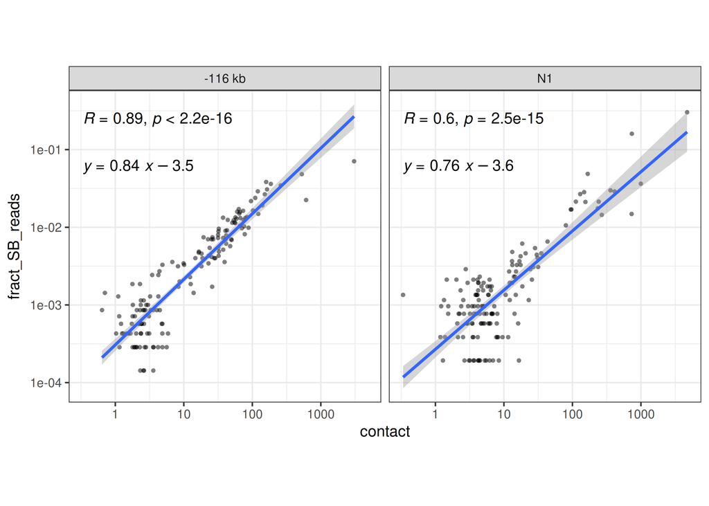

```r
SB_ints_by_contact_tib_25kb %>%
  mutate(dist_from_LP = abs(mid_bin - start)) %>%
  filter(contact > 0 & N_SB_reads> 0 & dist_from_LP ) %>%
  ggplot(aes(x = contact , y = fract_SB_reads)) +
  facet_wrap( ~ LP) +
  stat_cor(label.y.npc = 'top', vjust = 1, method = 'spearman') +
  geom_point(alpha = 0.5, stroke = NA)+
  geom_smooth(method = 'lm') +
  stat_regline_equation(label.y.npc = 0.8)+
  scale_x_log10()+
  scale_y_log10()+
  theme_bw() +
  theme(legend.position =  'none',
        aspect.ratio = 1)
```

Calculate slopes more exactly

```r
SB_ints_by_contact_tib_25kb_norm = SB_ints_by_contact_tib_25kb %>%
  filter(contact > 0 & fract_SB_reads > 0 ) %>%
  mutate(log10_fract_reads = log10(fract_SB_reads),
         log10_contact = log10(contact))

contact_slope_tib = SB_ints_by_contact_tib_25kb_norm %>%
  group_by(LP) %>%
  summarize(slope = lm(log10_fract_reads ~ log10_contact)$coefficients['log10_contact'],
            intercept = lm(log10_fract_reads ~ log10_contact)$coefficients['(Intercept)'],
            pearson_cor = cor.test(log10_fract_reads, log10_contact, method = 'pearson')$estimate,
            pearson_pval = cor.test(log10_fract_reads, log10_contact, method = 'pearson')$p.val)

contact_slope_tib
```

```
## # A tibble: 2 × 5
##   LP      slope intercept pearson_cor pearson_pval
##   <chr>   <dbl>     <dbl>       <dbl>        <dbl>
## 1 -116 kb 0.844     -3.51       0.914     1.02e-60
## 2 N1      0.762     -3.57       0.811     4.91e-35
```

Slopes are 0.84 (-116 kb) and 0.76 (N1).